# Multiple Linear Regression and Regression Diagnostics

Natasha umulisa RUTAGENGWA

# 1 Introduction

We will use the built-in swiss dataset in R.

It contains information about 47 French-speaking Swiss provinces and six variables.

```r
# Load the Swiss dataset
data(swiss)

# Display the first few records
head(swiss)
```

```
##              Fertility Agriculture Examination Education Catholic
## Courtelary        80.2        17.0          15        12     9.96
## Delemont          83.1        45.1           6         9    84.84
## Franches-Mnt      92.5        39.7           5         5    93.40
## Moutier           85.8        36.5          12         7    33.77
## Neuveville        76.9        43.5          17        15     5.16
## Porrentruy        76.1        35.3           9         7    90.57
##              Infant.Mortality
## Courtelary               22.2
## Delemont                 22.2
## Franches-Mnt             20.2
## Moutier                  20.3
## Neuveville               20.6
## Porrentruy               26.6
```

## 1.1 1.3 Examine the dataset structure

```r
# Check the structure of the dataset
str(swiss)
```

```
## 'data.frame':    47 obs. of  6 variables:
##  $ Fertility       : num  80.2 83.1 92.5 85.8 76.9 76.1 83.8 92.4 82.4 82.9 ...
##  $ Agriculture     : num  17 45.1 39.7 36.5 43.5 35.3 70.2 67.8 53.3 45.2 ...
##  $ Examination     : int  15 6 5 12 17 9 16 14 12 16 ...
##  $ Education       : int  12 9 5 7 15 7 7 8 7 13 ...
##  $ Catholic        : num  9.96 84.84 93.4 33.77 5.16 ...
##  $ Infant.Mortality: num  22.2 22.2 20.2 20.3 20.6 26.6 23.6 24.9 21 24.4 ...
```

```r
# Find the number of observations and variables
dim(swiss)
```

```
## [1] 47  6
```

```r
# Display all variable names
colnames(swiss)
```

```
## [1] "Fertility"        "Agriculture"      "Examination"      "Education"
## [5] "Catholic"         "Infant.Mortality"
```

The dataset contains 47 observations and six variables. Fertility is the dependent variable, while the other five variables are independent variables.

## 1.2 1.4 Check for missing values

```r
# Check missing values in each variable
colSums(is.na(swiss))
```

```
##        Fertility      Agriculture      Examination        Education
##                0                0                0                0
##         Catholic Infant.Mortality
##                0                0
```

```r
# Count all missing values
sum(is.na(swiss))
```

```
## [1] 0
```

Missing values must be investigated before fitting a regression model because they can affect the number of observations used in the analysis.

## 1.3 1.5 Descriptive statistics

```r
# Summary statistics
summary(swiss)
```

```
##    Fertility      Agriculture     Examination      Education
##  Min.   :35.00   Min.   : 1.20   Min.   : 3.00   Min.   : 1.00
##  1st Qu.:64.70   1st Qu.:35.90   1st Qu.:12.00   1st Qu.: 6.00
##  Median :70.40   Median :54.10   Median :16.00   Median : 8.00
##  Mean   :70.14   Mean   :50.66   Mean   :16.49   Mean   :10.98
##  3rd Qu.:78.45   3rd Qu.:67.65   3rd Qu.:22.00   3rd Qu.:12.00
##  Max.   :92.50   Max.   :89.70   Max.   :37.00   Max.   :53.00
##     Catholic       Infant.Mortality
##  Min.   :  2.150   Min.   :10.80
##  1st Qu.:  5.195   1st Qu.:18.15
##  Median : 15.140   Median :20.00
##  Mean   : 41.144   Mean   :19.94
##  3rd Qu.: 93.125   3rd Qu.:21.70
##  Max.   :100.000   Max.   :26.60
```

```r
# Calculate means
sapply(swiss, mean)
```

```
##        Fertility      Agriculture      Examination        Education
##         70.14255         50.65957         16.48936         10.97872
##         Catholic Infant.Mortality
##         41.14383         19.94255
```

```r
# Calculate standard deviations
sapply(swiss, sd)
```

```
##        Fertility      Agriculture      Examination        Education
##        12.491697        22.711218         7.977883         9.615407
##         Catholic Infant.Mortality
##        41.704850         2.912697
```

Descriptive statistics provide information about the distribution of the variables, including their minimum, maximum, median, mean, and variability.

# 2 2. Exploratory Data Analysis

Exploratory data analysis helps us understand the relationships between the variables before fitting a regression model.

## 2.1 2.1 Correlation analysis

```r
# Calculate relationships among all variables
correlation_results <- cor(swiss)

# Display the correlation values
round(correlation_results, 2)
```

```
##                  Fertility Agriculture Examination Education Catholic
## Fertility             1.00        0.35       -0.65     -0.66     0.46
## Agriculture           0.35        1.00       -0.69     -0.64     0.40
## Examination          -0.65       -0.69        1.00      0.70    -0.57
## Education            -0.66       -0.64        0.70      1.00    -0.15
## Catholic              0.46        0.40       -0.57     -0.15     1.00
## Infant.Mortality      0.42       -0.06       -0.11     -0.10     0.18
##                  Infant.Mortality
## Fertility                    0.42
## Agriculture                 -0.06
## Examination                 -0.11
## Education                   -0.10
## Catholic                     0.18
## Infant.Mortality             1.00
```

Correlation coefficients range from -1 to +1.

- A positive correlation indicates that two variables tend to increase together.
- A negative correlation indicates that one variable tends to decrease when the other increases.
- A correlation close to zero indicates a weak linear relationship.

Correlation does not necessarily imply causation.

## 2.2 2.2 Visualize relationships between variables

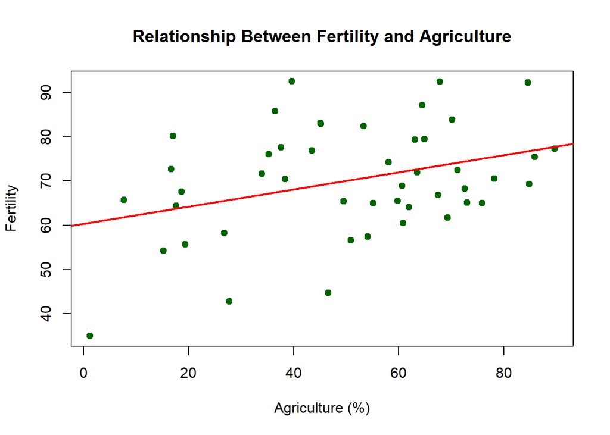

```r
# Examine the relationship between fertility and agriculture
plot(swiss$Agriculture, swiss$Fertility,
     main = "Relationship Between Fertility and Agriculture",
     xlab = "Agriculture (%)",
     ylab = "Fertility",
     pch = 19,
     col = "darkgreen")

# Add a regression line
abline(lm(Fertility ~ Agriculture, data = swiss),
       col = "red", lwd = 2)
```

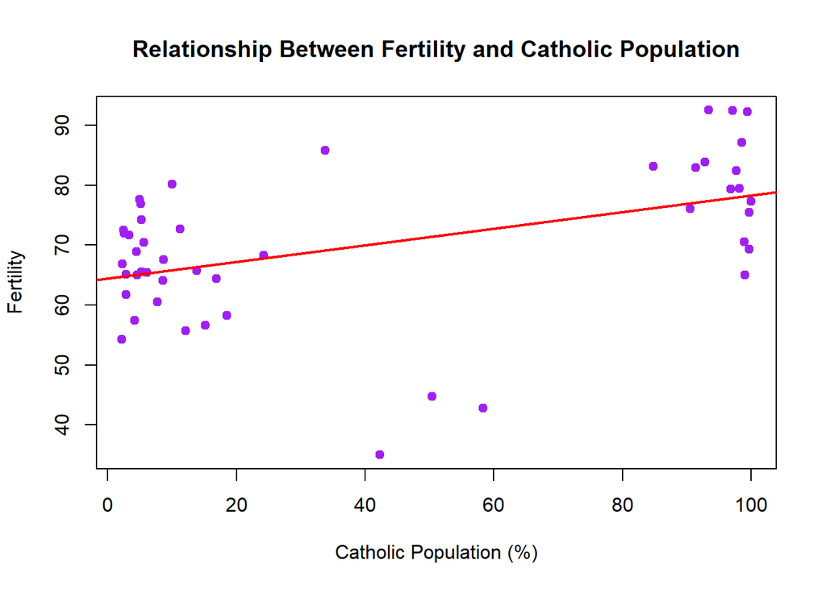

```r
# Examine the relationship between fertility and Catholic population
plot(swiss$Catholic, swiss$Fertility,
     main = "Relationship Between Fertility and Catholic Population",
     xlab = "Catholic Population (%)",
     ylab = "Fertility",
     pch = 19,
     col = "purple")

# Add a regression line
abline(lm(Fertility ~ Catholic, data = swiss),
       col = "red", lwd = 2)
```

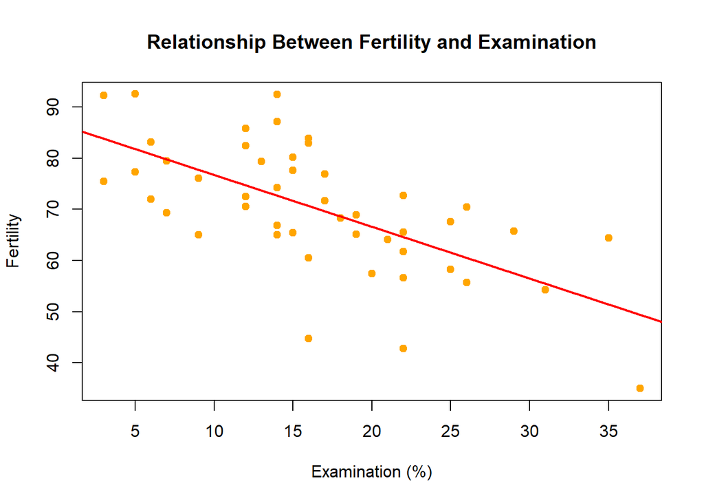

```r
# Examine the relationship between fertility and examination
plot(swiss$Examination, swiss$Fertility,
     main = "Relationship Between Fertility and Examination",
     xlab = "Examination (%)",
     ylab = "Fertility",
     pch = 19,
     col = "orange")

# Add a regression line
abline(lm(Fertility ~ Examination, data = swiss),
       col = "red", lwd = 2)
```

The scatter plots help identify whether the relationships between fertility and the explanatory variables appear positive, negative, or nonlinear.

# 3 3. Multiple Linear Regression

## 3.1 3.1 Model specification

The dependent variable is Fertility.

The independent variables are Agriculture, Examination, Education, Catholic, and Infant.Mortality.

The regression model is:

$$Fertility = \beta_0 + \beta_1 Agriculture
+ \beta_2 Examination + \beta_3 Education
+ \beta_4 Catholic + \beta_5 Infant.Mortality
+ \epsilon$$

## 3.2 3.2 Fit the multiple linear regression model

```r
# Fit multiple linear regression model
model <- lm(Fertility ~ Agriculture +
              Examination +
              Education +
              Catholic +
              Infant.Mortality,
            data = swiss)

# Display regression results
summary(model)
```

```
##
## Call:
## lm(formula = Fertility ~ Agriculture + Examination + Education +
##     Catholic + Infant.Mortality, data = swiss)
##
## Residuals:
##      Min       1Q   Median       3Q      Max
## -15.2743  -5.2617   0.5032   4.1198  15.3213
##
## Coefficients:
##                  Estimate Std. Error t value Pr(>|t|)
## (Intercept)      66.91518   10.70604   6.250 1.91e-07 ***
## Agriculture      -0.17211    0.07030  -2.448  0.01873 *
## Examination      -0.25801    0.25388  -1.016  0.31546
## Education        -0.87094    0.18303  -4.758 2.43e-05 ***
## Catholic          0.10412    0.03526   2.953  0.00519 **
## Infant.Mortality  1.07705    0.38172   2.822  0.00734 **
## ---
## Signif. codes:  0 '***' 0.001 '**' 0.01 '*' 0.05 '.' 0.1 ' ' 1
##
## Residual standard error: 7.165 on 41 degrees of freedom
## Multiple R-squared:  0.7067, Adjusted R-squared:  0.671
## F-statistic: 19.76 on 5 and 41 DF,  p-value: 5.594e-10
```

The `lm()` function estimates the regression coefficients using the Ordinary Least Squares (OLS) method.

## 3.3 3.3 Interpret regression coefficients

```r
# Extract regression coefficients
coef(model)
```

```
##      (Intercept)      Agriculture      Examination        Education
##       66.9151817       -0.1721140       -0.2580082       -0.8709401
##         Catholic Infant.Mortality
##        0.1041153        1.0770481
```

The regression coefficients explain how the predicted fertility rate changes when an independent variable increases by one unit, holding all other independent variables constant.

- A positive coefficient indicates a positive conditional association with fertility.
- A negative coefficient indicates a negative conditional association with fertility.
- A coefficient close to zero indicates a small estimated change per unit.

The intercept represents the predicted fertility when all independent variables equal zero. It may not have a meaningful practical interpretation if that combination is outside the observed data.

## 3.4 3.4 Display the coefficient table

```r
# Extract coefficient estimates and statistical tests
coefficients_table <- as.data.frame(
  summary(model)$coefficients
)

# Rename columns
colnames(coefficients_table) <- c(
  "Estimate",
  "Standard Error",
  "t value",
  "p value"
)

knitr::kable(
  round(coefficients_table, 4),
  caption = "Multiple Linear Regression Coefficients"
)
```

Multiple Linear Regression Coefficients

|  | Estimate | Standard Error | t value | p value |
| --- | --- | --- | --- | --- |
| (Intercept) | 66.9152 | 10.7060 | 6.2502 | 0.0000 |
| Agriculture | -0.1721 | 0.0703 | -2.4481 | 0.0187 |
| Examination | -0.2580 | 0.2539 | -1.0163 | 0.3155 |
| Education | -0.8709 | 0.1830 | -4.7585 | 0.0000 |
| Catholic | 0.1041 | 0.0353 | 2.9530 | 0.0052 |
| Infant.Mortality | 1.0770 | 0.3817 | 2.8216 | 0.0073 |

## 3.5 3.5 Interpret individual variable significance

We use a 5% significance level.

```r
# Extract p-values
p_values <- summary(model)$coefficients[, 4]

# Display significance interpretation
for (variable in names(p_values)) {

  if (p_values[variable] < 0.05) {
    cat(variable,
        ": Statistically significant (p-value < 0.05)\n")
  } else {
    cat(variable,
        ": Not statistically significant (p-value >= 0.05)\n")
  }
}
```

```
## (Intercept) : Statistically significant (p-value < 0.05)
## Agriculture : Statistically significant (p-value < 0.05)
## Examination : Not statistically significant (p-value >= 0.05)
## Education : Statistically significant (p-value < 0.05)
## Catholic : Statistically significant (p-value < 0.05)
## Infant.Mortality : Statistically significant (p-value < 0.05)
```

A p-value below 0.05 indicates statistically significant evidence against the null hypothesis that the corresponding coefficient is zero, conditional on the other variables in the model.

A p-value greater than or equal to 0.05 means that the analysis does not provide sufficient evidence to reject the null hypothesis.

## 3.6 3.6 Evaluate model goodness of fit

```r
# Display model R-squared
summary(model)$r.squared
```

```
## [1] 0.706735
```

```r
# Display adjusted R-squared
summary(model)$adj.r.squared
```

```
## [1] 0.670971
```

```r
# Display residual standard error
summary(model)$sigma
```

```
## [1] 7.165369
```

```r
# Display F-statistic
summary(model)$fstatistic
```

```
##    value    numdf    dendf
## 19.76106  5.00000 41.00000
```

### 3.6.1 Interpretation of R-squared

R-squared measures the proportion of variation in fertility explained by the independent variables included in the regression model.

For example, an R-squared of 0.80 would indicate that 80% of the observed variation in fertility is explained by the fitted model.

Adjusted R-squared accounts for the number of explanatory variables and is useful when evaluating models containing multiple predictors.

### 3.6.2 Overall model significance

The F-test evaluates whether the explanatory variables jointly provide evidence of a linear relationship with fertility.

The hypotheses are:

$$H_0: \beta_1=\beta_2=\beta_3=\beta_4=\beta_5=0$$

$$H_1: \text{At least one } \beta_i \ne 0$$

```r
# Extract F-statistic and p-value
model_f <- summary(model)$fstatistic

f_value <- unname(model_f[1])
f_p_value <- pf(
  f_value,
  model_f[2],
  model_f[3],
  lower.tail = FALSE
)

cat("F-statistic:", f_value, "\n")
```

```
## F-statistic: 19.76106
```

```r
cat("Overall model p-value:", f_p_value, "\n")
```

```
## Overall model p-value: 5.593799e-10
```

```r
if (f_p_value < 0.05) {
  cat("Conclusion: Reject the null hypothesis.\n")
  cat("The regression model is statistically significant.\n")
} else {
  cat("Conclusion: Fail to reject the null hypothesis.\n")
  cat("The regression model is not statistically significant at 5%.\n")
}
```

```
## Conclusion: Reject the null hypothesis.
## The regression model is statistically significant.
```

# 4 4. Regression Diagnostics

Regression diagnostics help determine whether the assumptions of multiple linear regression are reasonably satisfied.

## 4.1 4.1 Linearity assumption

Linearity means that the expected value of the dependent variable is a linear function of the model predictors.

We use a residuals-versus-fitted plot to investigate this assumption.

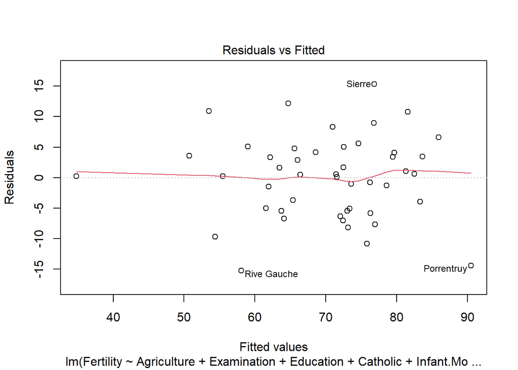

```r
plot(model, which = 1)
```

Interpretation:

- A random distribution of residuals around zero supports the linearity assumption.
- A clear curved pattern may indicate a nonlinear relationship.
- A systematic pattern suggests that the model may be missing important structure.

## 4.2 4.2 Normality of residuals

The normality assumption states that the regression errors are approximately normally distributed for the usual small-sample t and F inference.

We examine a histogram, a Q-Q plot, and the Shapiro-Wilk test.

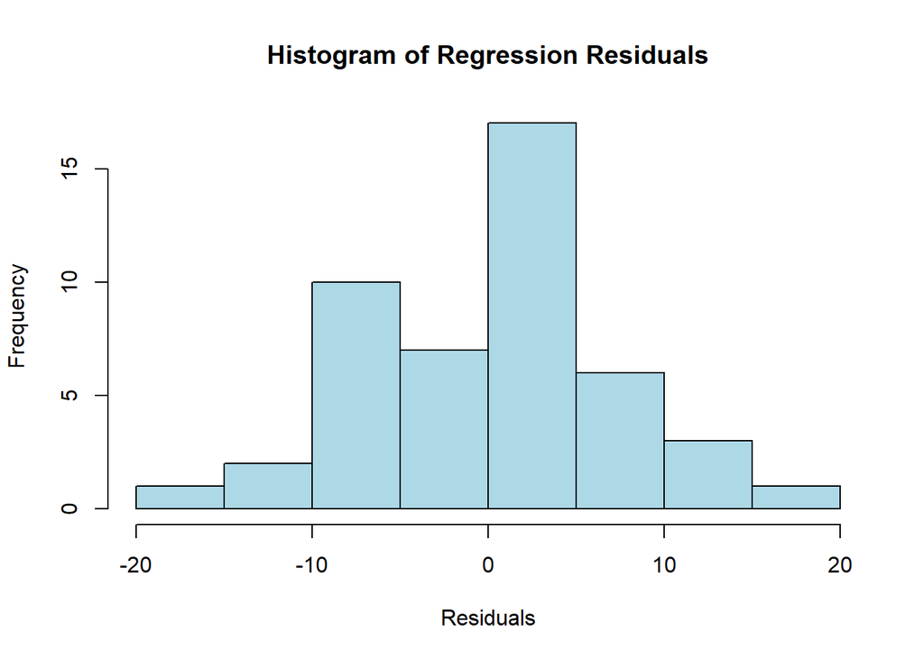

```r
# Calculate model residuals
residuals_model <- residuals(model)

# Histogram
hist(residuals_model,
     main = "Histogram of Regression Residuals",
     xlab = "Residuals",
     col = "lightblue",
     border = "black")
```

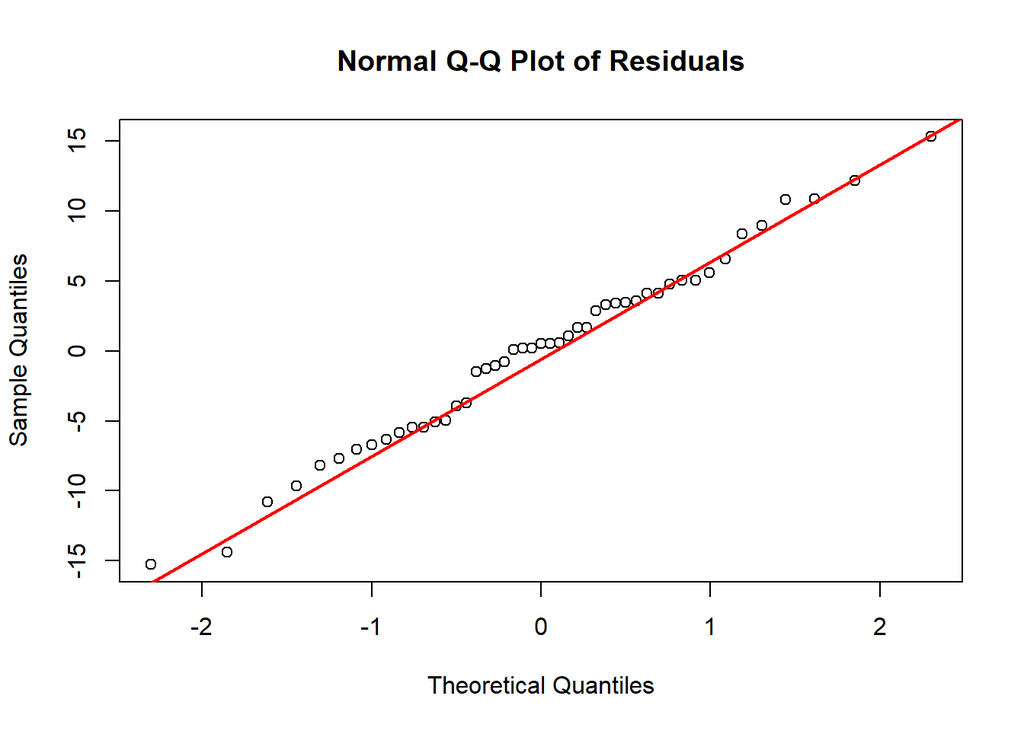

```r
# Normal Q-Q plot
qqnorm(residuals_model,
       main = "Normal Q-Q Plot of Residuals")

qqline(residuals_model,
       col = "red",
       lwd = 2)
```

### 4.2.1 Shapiro-Wilk normality test

Hypotheses:

$$H_0: \text{Residuals are normally distributed}$$

$$H_1: \text{Residuals are not normally distributed}$$

```r
# Perform Shapiro-Wilk test
shapiro_result <- shapiro.test(residuals_model)

shapiro_result
```

```
##
##  Shapiro-Wilk normality test
##
## data:  residuals_model
## W = 0.98892, p-value = 0.9318
```

```r
# Interpret the test
if (shapiro_result$p.value > 0.05) {
  cat("Fail to reject H0: There is insufficient evidence of non-normality.\n")
} else {
  cat("Reject H0: There is evidence that residuals are not normally distributed.\n")
}
```

```
## Fail to reject H0: There is insufficient evidence of non-normality.
```

A p-value greater than 0.05 indicates that the test does not find sufficient evidence against normality. It does not prove that the residuals are normally distributed.

## 4.3 4.3 Homoscedasticity assumption

Homoscedasticity means that the variance of the regression errors remains approximately constant across different fitted values.

We use a residual plot and the Breusch-Pagan test.

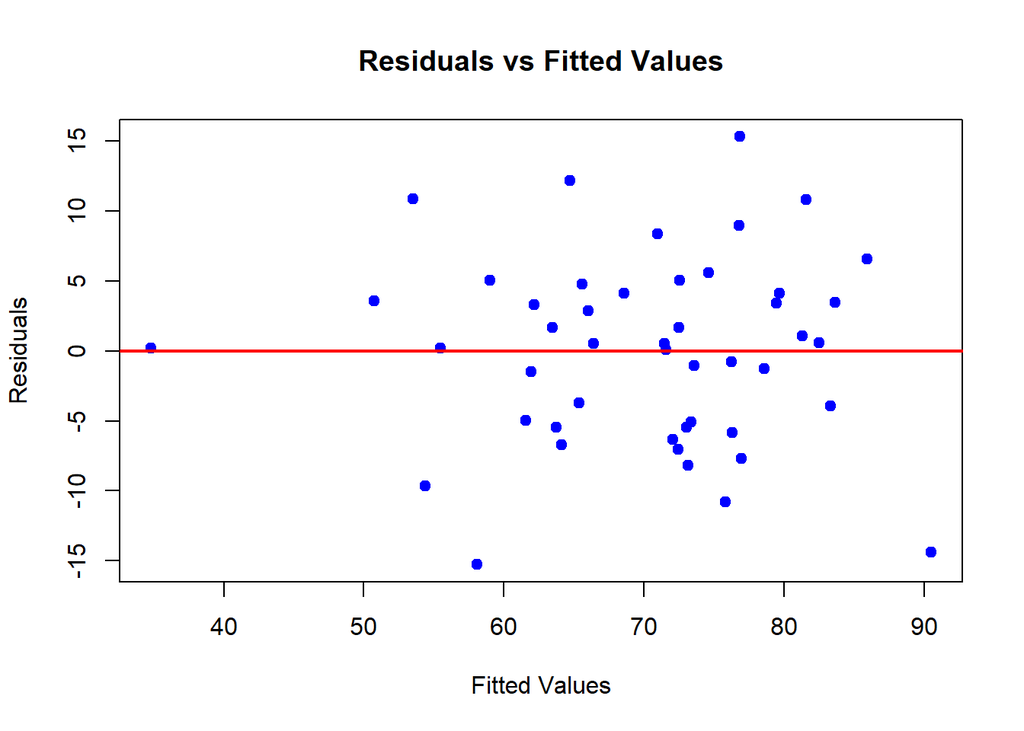

```r
# Residuals versus fitted values
plot(fitted(model),
     residuals_model,
     main = "Residuals vs Fitted Values",
     xlab = "Fitted Values",
     ylab = "Residuals",
     pch = 19,
     col = "blue")

abline(h = 0, col = "red", lwd = 2)
```

### 4.3.1 Breusch-Pagan test

Hypotheses:

$$H_0: \text{The error variance is constant}$$

$$H_1: \text{The error variance is not constant}$$

```r
# Breusch-Pagan test using an auxiliary regression
bp_auxiliary <- lm(
  I(residuals_model^2) ~ Agriculture +
    Examination +
    Education +
    Catholic +
    Infant.Mortality,
  data = swiss
)

# Calculate the test statistic
bp_statistic <- nrow(swiss) *
  summary(bp_auxiliary)$r.squared

# Calculate p-value using chi-square distribution
bp_p_value <- pchisq(
  bp_statistic,
  df = 5,
  lower.tail = FALSE
)

cat("Breusch-Pagan LM statistic:", bp_statistic, "\n")
```

```
## Breusch-Pagan LM statistic: 5.851087
```

```r
cat("Breusch-Pagan p-value:", bp_p_value, "\n")
```

```
## Breusch-Pagan p-value: 0.3209795
```

```r
if (bp_p_value > 0.05) {
  cat("Fail to reject H0: No significant evidence of heteroscedasticity.\n")
} else {
  cat("Reject H0: Evidence of heteroscedasticity exists.\n")
}
```

```
## Fail to reject H0: No significant evidence of heteroscedasticity.
```

Interpretation:

- If the p-value is greater than 0.05, we do not find sufficient evidence of non-constant error variance.
- If the p-value is below 0.05, there is evidence of heteroscedasticity.

The test above uses the classical Breusch-Pagan auxiliary-regression approach.

## 4.4 4.4 Multicollinearity

Multicollinearity occurs when two or more independent variables are strongly linearly related.

It can increase the standard errors of regression coefficients and make individual effects difficult to distinguish.

We use the Variance Inflation Factor (VIF).

$$VIF_i = \frac{1}{1-R_i^2}$$

Where $R_i^2$ is obtained by regressing one independent variable on all the other independent variables.

```r
# Independent variables
predictors <- swiss[, c(
  "Agriculture",
  "Examination",
  "Education",
  "Catholic",
  "Infant.Mortality"
)]

# Function to calculate VIF without an additional package
calculate_vif <- function(data) {

  vif_values <- numeric(ncol(data))

  names(vif_values) <- names(data)

  for (i in seq_along(data)) {

    other_variables <- data[, -i, drop = FALSE]

    auxiliary_model <- lm(
      data[[i]] ~ .,
      data = other_variables
    )

    r_squared <- summary(auxiliary_model)$r.squared

    vif_values[i] <- 1 / (1 - r_squared)
  }

  return(vif_values)
}

# Calculate VIF values
vif_results <- calculate_vif(predictors)

vif_results
```

```
##      Agriculture      Examination        Education         Catholic
##         2.284129         3.675420         2.774943         1.937160
## Infant.Mortality
##         1.107542
```

Interpretation guidelines:

- VIF close to 1: Little multicollinearity.
- VIF between 1 and 5: Usually acceptable.
- VIF above 5: Possible multicollinearity concern.
- VIF above 10: Serious multicollinearity concern.

These are common guidelines rather than absolute statistical rules.

## 4.5 4.5 Influential observations and outliers

An influential observation is an observation that can substantially affect the estimated regression coefficients.

Cook’s distance helps identify potentially influential observations.

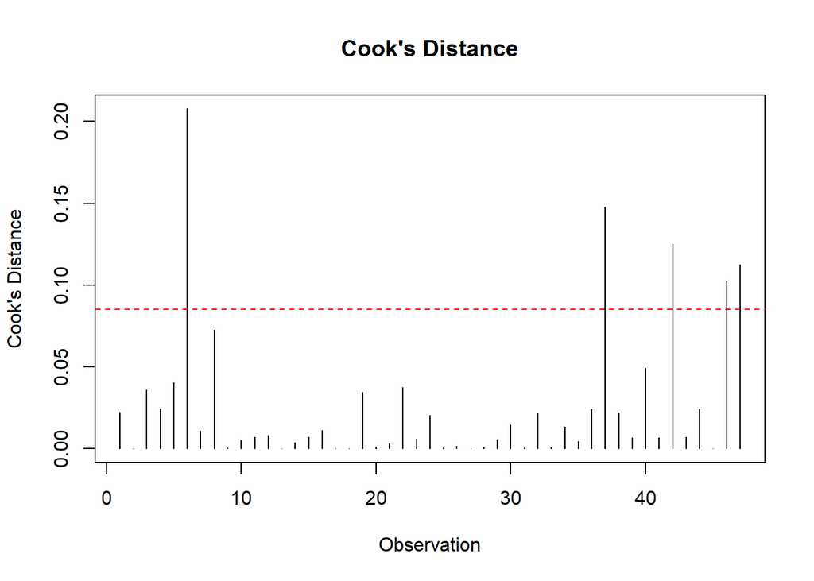

```r
# Calculate Cook's distance
cooks_distance <- cooks.distance(model)

# Plot Cook's distance
plot(cooks_distance,
     type = "h",
     main = "Cook's Distance",
     xlab = "Observation",
     ylab = "Cook's Distance")

# Reference threshold
abline(h = 4 / nrow(swiss),
       col = "red",
       lty = 2)
```

```r
# Identify observations above the reference threshold
influential_points <- which(
  cooks_distance > 4 / nrow(swiss)
)

influential_points
```

```
##  Porrentruy      Sierre   Neuchatel Rive Droite Rive Gauche
##           6          37          42          46          47
```

```r
# Display potentially influential observations
swiss[influential_points, ]
```

```
##             Fertility Agriculture Examination Education Catholic
## Porrentruy       76.1        35.3           9         7    90.57
## Sierre           92.2        84.6           3         3    99.46
## Neuchatel        64.4        17.6          35        32    16.92
## Rive Droite      44.7        46.6          16        29    50.43
## Rive Gauche      42.8        27.7          22        29    58.33
##             Infant.Mortality
## Porrentruy              26.6
## Sierre                  16.3
## Neuchatel               23.0
## Rive Droite             18.2
## Rive Gauche             19.3
```

The reference threshold of 4/n is a screening guideline, not an automatic rule for deleting observations.

Observations should be investigated before deciding whether they require special treatment.

## 4.6 4.6 Additional regression diagnostic plots

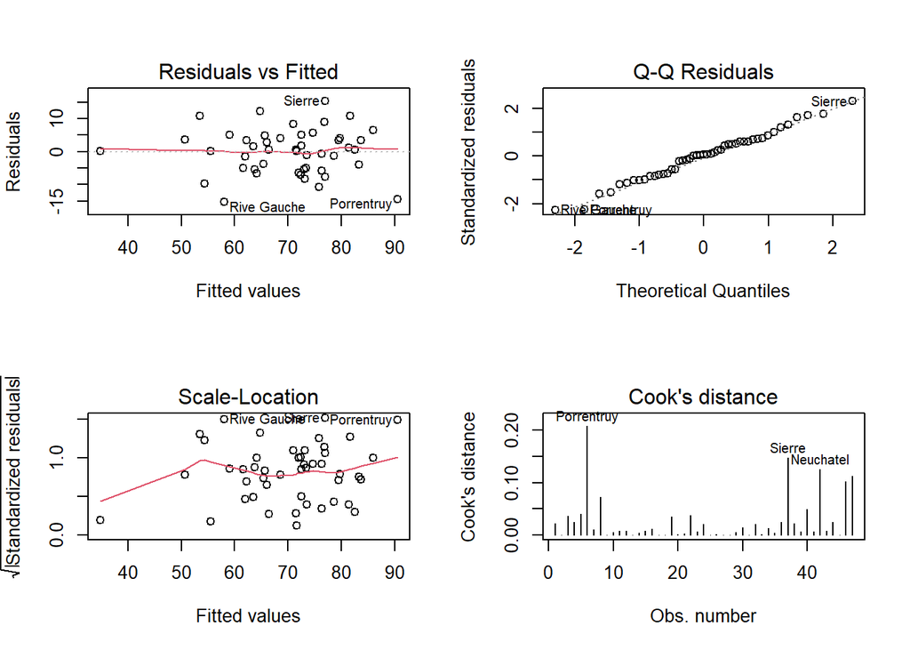

```r
# Display four standard regression diagnostic plots
par(mfrow = c(2, 2))

plot(model, which = 1)
plot(model, which = 2)
plot(model, which = 3)
plot(model, which = 4)
```

```r
# Restore the plotting layout
par(mfrow = c(1, 1))
```

# 5 5. Model Prediction

After fitting the model, we can use it to predict fertility for a new observation with specified socioeconomic characteristics.

```r
# Create a new observation using the mean of each predictor
new_data <- data.frame(
  Agriculture = mean(swiss$Agriculture),
  Examination = mean(swiss$Examination),
  Education = mean(swiss$Education),
  Catholic = mean(swiss$Catholic),
  Infant.Mortality = mean(swiss$Infant.Mortality)
)

# Predict fertility
predicted_fertility <- predict(
  model,
  newdata = new_data,
  interval = "prediction"
)

predicted_fertility
```

```
##        fit      lwr      upr
## 1 70.14255 55.51866 84.76644
```

The prediction provides an estimated fertility value for a province with the specified predictor values.

The prediction interval represents uncertainty for an individual future observation, rather than just uncertainty about the mean response.

# 6 6. Results and Interpretation

The multiple linear regression model examines the joint association between fertility and five socioeconomic variables.

The coefficient estimates indicate the direction and magnitude of the conditional relationships, while the p-values help assess statistical significance.

The R-squared and adjusted R-squared values indicate how much variation in fertility is explained by the model.

The F-test evaluates whether the predictors are jointly statistically significant.

Regression diagnostic tests and plots are used to evaluate the suitability of the model assumptions.

# 7 7. Conclusion

This assignment demonstrated how multiple linear regression can be applied to investigate the relationship between a dependent variable and several independent variables.

The Swiss Fertility dataset was used to estimate a regression model with fertility as the dependent variable and agriculture, examination, education, Catholic population percentage, and infant mortality as explanatory variables.

The analysis covered descriptive statistics, correlation, visualization, regression estimation, coefficient interpretation, hypothesis testing, model goodness of fit, and regression diagnostics.

The diagnostic analysis is important because a statistically significant regression model is not automatically an appropriate model. Its assumptions must also be examined.

Finally, the results describe associations in historical observational data. They should not be interpreted as proof that the explanatory variables cause changes in fertility.

# 8 8. References

1. R Core Team. R: A Language and Environment for Statistical Computing.
2. R Documentation. `swiss` dataset, available in the datasets package.
3. R Documentation. `lm()` function for fitting linear models.
4. Montgomery, D. C., Peck, E. A., and Vining, G. G. Introduction to Linear Regression Analysis.